# **Facturación (df_facturacion, df_devoluciones,df_notascredito,df_clientes)**

# **Evidencia 1**

(15 puntos) Realiza la estadística descriptiva de la base de datos.

- Medidas de tendencia central, dispersión, análisis de cuartiles e incorporación de elementos gráficos para mostrar los datos

(15 puntos) Determina el conjunto de puntos (de filas y columnas) que establezcan el universo de datos apto para la modelación.

(30 puntos) Modeliza mediante por lo menos cuatro regresores (lineales y no-lineales) cuáles escenarios son los más favorables para la problemática.

- El entrenamiento y evaluación del modelo.
- Mencionar el error y/o la r2 ajustada.
- En caso de que consideren que algún método no es conveniente para su problema, justifiquen su respuesta

(30 puntos) Genera una ANOVA e intervalos de confianza (describe todo el proceso)

(10 puntos) Cada integrante del equipo redacte sus conclusiones personales

- ¿Cómo avanzó su proyecto con al aplicación de estas técnicas? (respecto a su primera entrega)
- Relaciona el objetivo de su proyecto con los avances que tienen hasta el momento

# **Preparación**

```python
!pip install funpymodeling
```

```python
import pandas as pd
import numpy as np
import matplotlib.pyplot as plt
import seaborn as sns
import matplotlib.pyplot as plt
from funpymodeling.exploratory import freq_tbl
```

```python
df_facturacion= pd.read_excel("FACTURACION_FINAL.xlsx",sheet_name = "FACTURACION")
df_facturacion.info()
```

```
<class 'pandas.core.frame.DataFrame'>
RangeIndex: 10752 entries, 0 to 10751
Data columns (total 12 columns):
 #   Column         Non-Null Count  Dtype
---  ------         --------------  -----
 0   CVE_DOC        10752 non-null  object
 1   CLIENTE        10752 non-null  object
 2   STATUS         10752 non-null  object
 3   VENDEDOR       10752 non-null  int64
 4   FECHA_ELAB     10752 non-null  datetime64[ns]
 5   FECHA_VEN      10752 non-null  datetime64[ns]
 6   FECHA_CANCELA  281 non-null    datetime64[ns]
 7   CAN_TOT        10752 non-null  float64
 8   DES_TOT        10752 non-null  float64
 9   TOTAL          10752 non-null  float64
 10  RFC            10752 non-null  object
 11  CAT_LB         10752 non-null  object
dtypes: datetime64[ns](3), float64(3), int64(1), object(5)
memory usage: 1008.1+ KB
```

```python
df_devoluciones= pd.read_excel("FACTURACION_FINAL.xlsx",sheet_name = "DEVOLUCIONES")
df_devoluciones.info()
```

```
<class 'pandas.core.frame.DataFrame'>
RangeIndex: 187 entries, 0 to 186
Data columns (total 14 columns):
 #   Column         Non-Null Count  Dtype
---  ------         --------------  -----
 0   TIP_OP         187 non-null    object
 1   CVE_DEV        187 non-null    object
 2   CLIENTE        187 non-null    object
 3   STATUS         187 non-null    object
 4   VENDEDOR       187 non-null    int64
 5   CVE_PEDI       187 non-null    object
 6   FECHA_VEN      187 non-null    datetime64[ns]
 7   FECHA_CANCELA  4 non-null      datetime64[ns]
 8   CAN_TOT        187 non-null    float64
 9   FECHA_ELAB     187 non-null    datetime64[ns]
 10  RFC            187 non-null    object
 11  FOLIO          187 non-null    int64
 12  CVE_DOC        181 non-null    object
 13  CAT_LB         187 non-null    object
dtypes: datetime64[ns](3), float64(1), int64(2), object(8)
memory usage: 20.6+ KB
```

```python
df_notascredito= pd.read_excel("FACTURACION_FINAL.xlsx",sheet_name = "NOTAS DE CREDITO")
df_notascredito.info()
```

```
<class 'pandas.core.frame.DataFrame'>
RangeIndex: 498 entries, 0 to 497
Data columns (total 13 columns):
 #   Column         Non-Null Count  Dtype
---  ------         --------------  -----
 0   TIP_OP         498 non-null    object
 1   CVE_NC         498 non-null    object
 2   CLIENTE        498 non-null    int64
 3   STATUS         498 non-null    object
 4   VENDEDOR       498 non-null    int64
 5   CVE_PEDI       498 non-null    object
 6   FECHA_VEN      498 non-null    datetime64[ns]
 7   FECHA_CANCELA  14 non-null     datetime64[ns]
 8   CAN_TOT        498 non-null    float64
 9   FECHA_ELAB     498 non-null    datetime64[ns]
 10  RFC            498 non-null    object
 11  FOLIO          498 non-null    int64
 12  QCUT           498 non-null    object
dtypes: datetime64[ns](3), float64(1), int64(3), object(6)
memory usage: 50.7+ KB
```

```python
df_clientes= pd.read_excel("FACTURACION_FINAL.xlsx",sheet_name = "CLIENTES")
df_clientes.info()
```

```
<class 'pandas.core.frame.DataFrame'>
RangeIndex: 5025 entries, 0 to 5024
Data columns (total 3 columns):
 #   Column   Non-Null Count  Dtype
---  ------   --------------  -----
 0   CLIENTE  5025 non-null   object
 1   RFC      5010 non-null   object
 2   NOMBRE   5024 non-null   object
dtypes: object(3)
memory usage: 117.9+ KB
```

# **Limpieza de outliers**

## **df_facturacion**

```python
#Método aplicando Cuartiles. Encuentro cuartiles 0.25 y 0.75
fac=df_facturacion[["CAN_TOT","TOTAL"]]

percentile25=fac.quantile(0.25) #Q1
percentile75=fac.quantile(0.75) #Q3
iqr= percentile75 - percentile25

Limite_Superior_iqr= percentile75 + 1.5*iqr
Limite_Inferior_iqr= percentile25 - 1.5*iqr
print("Limite superior permitido", Limite_Superior_iqr)
print()
print("Limite inferior permitido", Limite_Inferior_iqr)
```

```
Limite superior permitido CAN_TOT    9106.72500
TOTAL      9097.95625
dtype: float64

Limite inferior permitido CAN_TOT   -4551.23500
TOTAL     -4545.97375
dtype: float64
```

```python
#Encontramos Outliers del Dataframe
outliers_iqr= fac[(fac>Limite_Superior_iqr)|(fac<Limite_Inferior_iqr)]
outliers_iqr
```

|  | CAN_TOT | TOTAL |
| --- | --- | --- |
| 0 | NaN | NaN |
| 1 | NaN | NaN |
| 2 | NaN | NaN |
| 3 | NaN | NaN |
| 4 | NaN | NaN |
| ... | ... | ... |
| 10747 | NaN | NaN |
| 10748 | NaN | NaN |
| 10749 | NaN | NaN |
| 10750 | NaN | NaN |
| 10751 | NaN | NaN |

10752 rows × 2 columns

```python
#Obtenemos datos limpios del Dataframe
facturacion_iqr= fac[(fac<=Limite_Superior_iqr)&(fac>=Limite_Inferior_iqr)]
facturacion_iqr
```

|  | CAN_TOT | TOTAL |
| --- | --- | --- |
| 0 | 3980.000 | 3980.000 |
| 1 | 1550.000 | 1550.000 |
| 2 | 2435.440 | 2435.440 |
| 3 | 3979.998 | 3979.998 |
| 4 | 402.590 | 402.590 |
| ... | ... | ... |
| 10747 | 2178.000 | 2178.000 |
| 10748 | 607.250 | 607.250 |
| 10749 | 567.757 | 567.757 |
| 10750 | 1944.950 | 1944.950 |
| 10751 | 6813.000 | 6813.000 |

10752 rows × 2 columns

```python
#Corroboramos valores nulos del dataframe LIMPIO
valores_nulos=facturacion_iqr.isnull().sum()
valores_nulos
```

```
CAN_TOT    1183
TOTAL      1181
dtype: int64
```

```python
#Reemplazamos valores atípicos (nulos) del dataframe con "mean"
#Realizamos una copia del dataframe
facturacion_iqr_final=facturacion_iqr.copy()
facturacion_iqr_final=facturacion_iqr_final.fillna(round(facturacion_iqr.mean(),1))
facturacion_iqr_final
```

|  | CAN_TOT | TOTAL |
| --- | --- | --- |
| 0 | 3980.000 | 3980.000 |
| 1 | 1550.000 | 1550.000 |
| 2 | 2435.440 | 2435.440 |
| 3 | 3979.998 | 3979.998 |
| 4 | 402.590 | 402.590 |
| ... | ... | ... |
| 10747 | 2178.000 | 2178.000 |
| 10748 | 607.250 | 607.250 |
| 10749 | 567.757 | 567.757 |
| 10750 | 1944.950 | 1944.950 |
| 10751 | 6813.000 | 6813.000 |

10752 rows × 2 columns

## **df_devoluciones (dev)**

```python
#Método aplicando Cuartiles. Encuentro cuartiles 0.25 y 0.75
dev=df_devoluciones[["CAN_TOT"]]

percentile25=dev.quantile(0.25) #Q1
percentile75=dev.quantile(0.75) #Q3
iqr= percentile75 - percentile25

Limite_Superior_iqr= percentile75 + 1.5*iqr
Limite_Inferior_iqr= percentile25 - 1.5*iqr
print("Limite superior permitido", Limite_Superior_iqr)
print()
print("Limite inferior permitido", Limite_Inferior_iqr)
```

```
Limite superior permitido CAN_TOT    24138.153125
dtype: float64

Limite inferior permitido CAN_TOT   -10970.091875
dtype: float64
```

```python
#Encontramos Outliers del Dataframe
outliers_iqr= dev[(dev>Limite_Superior_iqr)|(dev<Limite_Inferior_iqr)]
outliers_iqr
```

|  | CAN_TOT |
| --- | --- |
| 0 | 50994.0 |
| 1 | NaN |
| 2 | NaN |
| 3 | NaN |
| 4 | NaN |
| ... | ... |
| 182 | NaN |
| 183 | NaN |
| 184 | NaN |
| 185 | NaN |
| 186 | NaN |

187 rows × 1 columns

```python
#Obtenemos datos limpios del Dataframe
devoluciones_iqr= dev[(dev<=Limite_Superior_iqr)&(dev>=Limite_Inferior_iqr)]
devoluciones_iqr
```

|  | CAN_TOT |
| --- | --- |
| 0 | NaN |
| 1 | 7125.90 |
| 2 | 2726.52 |
| 3 | 1363.26 |
| 4 | 4232.25 |
| ... | ... |
| 182 | 4880.00 |
| 183 | 17768.00 |
| 184 | 8816.00 |
| 185 | 4070.00 |
| 186 | 1660.00 |

187 rows × 1 columns

```python
#Corroboramos valores nulos del dataframe LIMPIO
valores_nulos=devoluciones_iqr.isnull().sum()
valores_nulos
```

```
CAN_TOT    17
dtype: int64
```

```python
#Reemplazamos valores atípicos (nulos) del dataframe con "mean"
#Realizamos una copia del dataframe
devoluciones_iqr_final=devoluciones_iqr.copy()
devoluciones_iqr_final=devoluciones_iqr.fillna(round(devoluciones_iqr.mean(),1))
devoluciones_iqr_final
```

|  | CAN_TOT |
| --- | --- |
| 0 | 5883.20 |
| 1 | 7125.90 |
| 2 | 2726.52 |
| 3 | 1363.26 |
| 4 | 4232.25 |
| ... | ... |
| 182 | 4880.00 |
| 183 | 17768.00 |
| 184 | 8816.00 |
| 185 | 4070.00 |
| 186 | 1660.00 |

187 rows × 1 columns

## **df_notascredito (nc)**

```python
#Método aplicando Cuartiles. Encuentro cuartiles 0.25 y 0.75
nc=df_notascredito[["CAN_TOT"]]

percentile25=nc.quantile(0.25) #Q1
percentile75=nc.quantile(0.75) #Q3
iqr= percentile75 - percentile25

Limite_Superior_iqr= percentile75 + 1.5*iqr
Limite_Inferior_iqr= percentile25 - 1.5*iqr
print("Limite superior permitido", Limite_Superior_iqr)
print()
print("Limite inferior permitido", Limite_Inferior_iqr)
```

```
Limite superior permitido CAN_TOT    9765.061625
dtype: float64

Limite inferior permitido CAN_TOT   -4491.489375
dtype: float64
```

```python
#Encontramos Outliers del Dataframe
outliers_iqr= nc[(nc>Limite_Superior_iqr)|(nc<Limite_Inferior_iqr)]
outliers_iqr
```

|  | CAN_TOT |
| --- | --- |
| 0 | NaN |
| 1 | NaN |
| 2 | NaN |
| 3 | 43103.4482 |
| 4 | NaN |
| ... | ... |
| 493 | NaN |
| 494 | NaN |
| 495 | NaN |
| 496 | NaN |
| 497 | NaN |

498 rows × 1 columns

```python
#Obtenemos datos limpios del Dataframe
notascredito_iqr= nc[(nc<=Limite_Superior_iqr)&(nc>=Limite_Inferior_iqr)]
notascredito_iqr
```

|  | CAN_TOT |
| --- | --- |
| 0 | 919.4560 |
| 1 | 852.2670 |
| 2 | 517.2410 |
| 3 | NaN |
| 4 | 258.6200 |
| ... | ... |
| 493 | 862.0689 |
| 494 | 2595.4137 |
| 495 | 350.0000 |
| 496 | 350.0000 |
| 497 | 3272.0000 |

498 rows × 1 columns

```python
#Corroboramos valores nulos del dataframe LIMPIO
valores_nulos=notascredito_iqr.isnull().sum()
valores_nulos
```

```
CAN_TOT    44
dtype: int64
```

```python
#Reemplazamos valores atípicos (nulos) del dataframe con "mean"
#Realizamos una copia del dataframe
notascredito_iqr_final=notascredito_iqr.copy()
notascredito_iqr_final=notascredito_iqr.fillna(round(notascredito_iqr.mean(),1))
notascredito_iqr_final
```

|  | CAN_TOT |
| --- | --- |
| 0 | 919.4560 |
| 1 | 852.2670 |
| 2 | 517.2410 |
| 3 | 2505.1000 |
| 4 | 258.6200 |
| ... | ... |
| 493 | 862.0689 |
| 494 | 2595.4137 |
| 495 | 350.0000 |
| 496 | 350.0000 |
| 497 | 3272.0000 |

498 rows × 1 columns

```python
df_facturacion['CAN_TOT'] = facturacion_iqr_final['CAN_TOT']
#df_facturacion['DES_TOT'] = facturacion_iqr_final['DES_TOT']
df_facturacion['TOTAL'] = facturacion_iqr_final['TOTAL']

df_devoluciones['CAN_TOT'] = devoluciones_iqr_final['CAN_TOT']

df_notascredito['CAN_TOT'] = notascredito_iqr_final['CAN_TOT']
```

# **Estadística Descriptiva**

Se realizaron los cálculos de la medidas de tendencia central correspondientes, además de dispersión de los datos, análisis de cuartiles e incorporación de elementos gráficos para mostrar los datos.

El cálculo de las medidas de tendencia central para las variables cuantitativas se realizó en Excel con el método de medidas de tendencia categorizadas como primer elemento. Al realizar este cálculo se determinó que el archivo original tenía outliers significativos, por lo que se realizaron dos tipos de limpieza; una manual en Excel y otra a través del método interquartílico en Google Colab.

La limpieza manual redujo el número de outliers, pero no logró una precisión cercana a 100% para el promedio. Por otro lado, la limpieza del archivo mediante el método de IQR logró resultados correctos para la columna de "CAN_TOT" en las 3 hojas (facturación, devoluciones y notas de crédito) pero no para la columna de "DES_TOT" en la hoja de facturacion. Por esa razón, se complementa con un análisis de medidas de tendencia central estándar, presentado a continuación:

```python
print("Estadística descriptiva de df_facturacion")
print()
print("Columna: CAN_TOT")
print("Promedio: ",df_facturacion["CAN_TOT"].mean())
print("Mediana: ",df_facturacion["CAN_TOT"].median())
print("Moda: ",df_facturacion["CAN_TOT"].mode())
print("Desviación estándar: ",df_facturacion["CAN_TOT"].std())
print("Varianza: ",df_facturacion["CAN_TOT"].var())
print("Q1: ",df_facturacion['CAN_TOT'].quantile(0.25))
print("Q2: ",df_facturacion['CAN_TOT'].quantile(0.50))
print("Q3: ",df_facturacion['CAN_TOT'].quantile(0.75))

print()
print("Columna: DES_TOT")
print("Se realizó con los datos originales sin limpieza de outliers dada la naturaleza de la columna")
print("Promedio: ",df_facturacion["DES_TOT"].mean())
print("Mediana: ",df_facturacion["DES_TOT"].median())
print("Moda: ",df_facturacion["DES_TOT"].mode())
print("Desviación estándar: ",df_facturacion["DES_TOT"].std())
print("Varianza: ",df_facturacion["DES_TOT"].var())
print("Q1: ",df_facturacion['DES_TOT'].quantile(0.25))
print("Q2: ",df_facturacion['DES_TOT'].quantile(0.50))
print("Q3: ",df_facturacion['DES_TOT'].quantile(0.75))

print()
print("Columna: TOTAL")
print("Promedio: ",df_facturacion["TOTAL"].mean())
print("Mediana: ",df_facturacion["TOTAL"].median())
print("Moda: ",df_facturacion["TOTAL"].mode())
print("Desviación estándar: ",df_facturacion["TOTAL"].std())
print("Varianza: ",df_facturacion["TOTAL"].var())
print("Q1: ",df_facturacion['TOTAL'].quantile(0.25))
print("Q2: ",df_facturacion['TOTAL'].quantile(0.50))
print("Q3: ",df_facturacion['TOTAL'].quantile(0.75))
```

```
Estadística descriptiva de df_facturacion

Columna: CAN_TOT
Promedio:  1967.8816406959636
Mediana:  1462.28
Moda:  0    1967.9
Name: CAN_TOT, dtype: float64
Desviación estándar:  1891.240391766376
Varianza:  3576790.219448635
Q1:  570.5
Q2:  1462.28
Q3:  2451.911

Columna: DES_TOT
Se realizó con los datos originales sin limpieza de outliers dada la naturaleza de la columna
Promedio:  17.85884951636905
Mediana:  0.0
Moda:  0    0.0
Name: DES_TOT, dtype: float64
Desviación estándar:  436.03791649867617
Varianza:  190129.0646245065
Q1:  0.0
Q2:  0.0
Q3:  0.0

Columna: TOTAL
Promedio:  1964.791168783761
Mediana:  1455.1662000000001
Moda:  0    1964.8
Name: TOTAL, dtype: float64
Desviación estándar:  1887.955087220293
Varianza:  3564374.411360984
Q1:  570.5
Q2:  1455.1662000000001
Q3:  2450.0
```

```python
print("Estadística descriptiva de df_devoluciones")
print()
print("Columna: CAN_TOT")
print("Promedio: ",df_devoluciones["CAN_TOT"].mean())
print("Mediana: ",df_devoluciones["CAN_TOT"].median())
print("Moda: ",df_devoluciones["CAN_TOT"].mode())
print("Desviación estándar: ",df_devoluciones["CAN_TOT"].std())
print("Varianza: ",df_devoluciones["CAN_TOT"].var())
print("Q1: ",df_devoluciones['CAN_TOT'].quantile(0.25))
print("Q2: ",df_devoluciones['CAN_TOT'].quantile(0.50))
print("Q3: ",df_devoluciones['CAN_TOT'].quantile(0.75))
```

```
Estadística descriptiva de df_devoluciones

Columna: CAN_TOT
Promedio:  5883.209042780749
Mediana:  4978.5
Moda:  0    5883.2
Name: CAN_TOT, dtype: float64
Desviación estándar:  4888.58111370416
Varianza:  23898225.305265006
Q1:  2195.5
Q2:  4978.5
Q3:  7485.637500000001
```

```python
print("Estadística descriptiva de df_notascredito")
print()
print("Columna: CAN_TOT")
print("Promedio: ",df_notascredito["CAN_TOT"].mean())
print("Mediana: ",df_notascredito["CAN_TOT"].median())
print("Moda: ",df_notascredito["CAN_TOT"].mode())
print("Desviación estándar: ",df_notascredito["CAN_TOT"].std())
print("Varianza: ",df_notascredito["CAN_TOT"].var())
print("Q1: ",df_notascredito['CAN_TOT'].quantile(0.25))
print("Q2: ",df_notascredito['CAN_TOT'].quantile(0.50))
print("Q3: ",df_notascredito['CAN_TOT'].quantile(0.75))
```

```
Estadística descriptiva de df_notascredito

Columna: CAN_TOT
Promedio:  2505.0939358433734
Mediana:  1997.1284
Moda:  0    2505.1
Name: CAN_TOT, dtype: float64
Desviación estándar:  2078.979400274559
Varianza:  4322155.346765965
Q1:  854.71725
Q2:  1997.1284
Q3:  3490.825425
```

# **Extracción de características (gráficos)**

## **df_facturacion**

Se eligieron las siguientes columnas categóricas: "CLIENTE","VENDEDOR","RFC","CAT_LB" porque representan una parte fundamental del análisis gráfico para mostrar su frecuencia y porcentaje. No se eligieron las columnas numéricas (a las que se analizó con estadística descripctiva) y tampoco se eligieron: CVE_DOC (debido a que es un índice único de documento de cada factura) y las columnas con tipo de datp de fecha.

```python
filtro = df_facturacion.loc[:,["CLIENTE","VENDEDOR","RFC","CAT_LB"]]
filtro['VENDEDOR'] = filtro['VENDEDOR'].replace(0, 'Sin registro')
```

```python
filtro.isnull().sum()
```

```
CLIENTE     0
VENDEDOR    0
RFC         0
CAT_LB      0
dtype: int64
```

```python
df=filtro
```

### **Columna CLIENTE**

```python
#Análisis variado de la columna
table1= freq_tbl(df['CLIENTE'])
table1
```

|  | CLIENTE | frequency | percentage | cumulative_perc |
| --- | --- | --- | --- | --- |
| 0 | 5926 | 1221 | 0.113560 | 0.113560 |
| 1 | 466 | 107 | 0.009952 | 0.123512 |
| 2 | 5728 | 100 | 0.009301 | 0.132812 |
| 3 | 2768 | 97 | 0.009022 | 0.141834 |
| 4 | 4598 | 94 | 0.008743 | 0.150577 |
| ... | ... | ... | ... | ... |
| 2153 | 342 | 1 | 0.000093 | 0.999628 |
| 2154 | 4454 | 1 | 0.000093 | 0.999721 |
| 2155 | 8299 | 1 | 0.000093 | 0.999814 |
| 2156 | 6918 | 1 | 0.000093 | 0.999907 |
| 2157 | 8873 | 1 | 0.000093 | 1.000000 |

2158 rows × 4 columns

```python
#Filtro de valores mayores al número seleccionado
Filtro= table1[table1['frequency']>=50]
Filtro
```

|  | CLIENTE | frequency | percentage | cumulative_perc |
| --- | --- | --- | --- | --- |
| 0 | 5926 | 1221 | 0.113560 | 0.113560 |
| 1 | 466 | 107 | 0.009952 | 0.123512 |
| 2 | 5728 | 100 | 0.009301 | 0.132812 |
| 3 | 2768 | 97 | 0.009022 | 0.141834 |
| 4 | 4598 | 94 | 0.008743 | 0.150577 |
| 5 | 1965 | 87 | 0.008092 | 0.158668 |
| 6 | 644 | 72 | 0.006696 | 0.165365 |
| 7 | 161 | 67 | 0.006231 | 0.171596 |
| 8 | 2385 | 64 | 0.005952 | 0.177548 |

```python
#Ajustar índice
Filtro_index= Filtro.set_index('CLIENTE')
Filtro_index
```

| CLIENTE | frequency | percentage | cumulative_perc |
| --- | --- | --- | --- |
| 5926 | 1221 | 0.113560 | 0.113560 |
| 466 | 107 | 0.009952 | 0.123512 |
| 5728 | 100 | 0.009301 | 0.132812 |
| 2768 | 97 | 0.009022 | 0.141834 |
| 4598 | 94 | 0.008743 | 0.150577 |
| 1965 | 87 | 0.008092 | 0.158668 |
| 644 | 72 | 0.006696 | 0.165365 |
| 161 | 67 | 0.006231 | 0.171596 |
| 2385 | 64 | 0.005952 | 0.177548 |

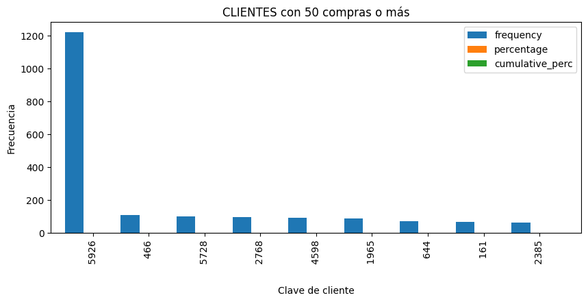

```python
#Gráfico de barras
Filtro_index.plot(kind = 'bar', width=1, figsize=(10,4))
plt.title('CLIENTES con 50 compras o más')
plt.xlabel('Clave de cliente')
plt.ylabel('Frecuencia')
```

Se puede observar que la clave de cliente con más registros es 5926. A continuación se coteja con el df de clientes para identificar los nombres

```python
indices_lista = Filtro["CLIENTE"].tolist()
indices_lista

resultados = df_clientes[df_clientes['CLIENTE'].isin(indices_lista)]
resultados
```

|  | CLIENTE | RFC | NOMBRE |
| --- | --- | --- | --- |
| 60 | 161 | LFO001002TH0 | LBQ FOUNDRY |
| 157 | 466 | DEA7103086X2 | DEACERO |
| 187 | 644 | CNC060201986 | CLAVOS NACIONALES C.N |
| 471 | 1965 | FEHJ671127LN2 | J. FRANCISCO FERRUZCA HERNANDEZ |
| 628 | 2385 | CIM0710049M6 | CARCOUSTICS INDUSTRIAL DE MEXICO |
| 784 | 2768 | CPA040625NA1 | CEREALES Y PASTAS |
| 1855 | 4598 | PSI8906083F8 | PROVEEDORA DE SEGURIDAD INDUSTRIAL DEL GOLFO |
| 2798 | 5728 | BACE861217GQ5 | ERIKA YUSSEL BLANCO CORTEZ |
| 2990 | 5926 | XAXX010101000 | PÚBLICO EN GENERAL |

### **Columna VENDEDOR**

```python
#Análisis variado de la columna
table2= freq_tbl(df['VENDEDOR'])
table2
```

|  | VENDEDOR | frequency | percentage | cumulative_perc |
| --- | --- | --- | --- | --- |
| 0 | 2 | 7590 | 0.705915 | 0.705915 |
| 1 | 1 | 961 | 0.089379 | 0.795294 |
| 2 | 3 | 892 | 0.082961 | 0.878255 |
| 3 | 6 | 445 | 0.041388 | 0.919643 |
| 4 | 5 | 417 | 0.038783 | 0.958426 |
| 5 | 4 | 381 | 0.035435 | 0.993862 |
| 6 | Sin registro | 45 | 0.004185 | 0.998047 |
| 7 | 11 | 12 | 0.001116 | 0.999163 |
| 8 | 10 | 6 | 0.000558 | 0.999721 |
| 9 | 9 | 1 | 0.000093 | 0.999814 |
| 10 | 7 | 1 | 0.000093 | 0.999907 |
| 11 | 12 | 1 | 0.000093 | 1.000000 |

```python
#Filtro de valores mayores al número seleccionado
Filtro= table2[table2['frequency']>1]
Filtro
```

|  | VENDEDOR | frequency | percentage | cumulative_perc |
| --- | --- | --- | --- | --- |
| 0 | 2 | 7590 | 0.705915 | 0.705915 |
| 1 | 1 | 961 | 0.089379 | 0.795294 |
| 2 | 3 | 892 | 0.082961 | 0.878255 |
| 3 | 6 | 445 | 0.041388 | 0.919643 |
| 4 | 5 | 417 | 0.038783 | 0.958426 |
| 5 | 4 | 381 | 0.035435 | 0.993862 |
| 6 | Sin registro | 45 | 0.004185 | 0.998047 |
| 7 | 11 | 12 | 0.001116 | 0.999163 |
| 8 | 10 | 6 | 0.000558 | 0.999721 |

```python
#Ajustar índice
Filtro_index= Filtro.set_index('VENDEDOR')
Filtro_index
```

| VENDEDOR | frequency | percentage | cumulative_perc |
| --- | --- | --- | --- |
| 2 | 7590 | 0.705915 | 0.705915 |
| 1 | 961 | 0.089379 | 0.795294 |
| 3 | 892 | 0.082961 | 0.878255 |
| 6 | 445 | 0.041388 | 0.919643 |
| 5 | 417 | 0.038783 | 0.958426 |
| 4 | 381 | 0.035435 | 0.993862 |
| Sin registro | 45 | 0.004185 | 0.998047 |
| 11 | 12 | 0.001116 | 0.999163 |
| 10 | 6 | 0.000558 | 0.999721 |

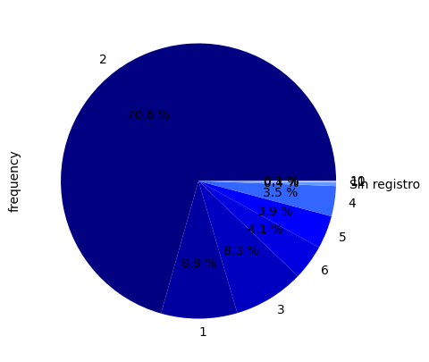

```python
#Gráfico de pastel
colors = ["#000080","#0000A0","#0000C0","#0000E0","#0000FF","#3366FF","#6699FF","#99CCFF","#CCE6FF"]
Filtro_index["frequency"].plot(kind='pie', figsize=(20,5), shadow=False, autopct="%0.1f %%", colors=colors)
plt.show()
```

### **Columna RFC**

```python
#Análisis variado de la columna
table3= freq_tbl(df['RFC'])
table3
```

|  | RFC | frequency | percentage | cumulative_perc |
| --- | --- | --- | --- | --- |
| 0 | XAXX 010101 000 | 1143 | 0.106306 | 0.106306 |
| 1 | DEA710308 6X2 | 100 | 0.009301 | 0.115606 |
| 2 | BACE 861217 GQ5 | 95 | 0.008836 | 0.124442 |
| 3 | XAXX010101000 | 91 | 0.008464 | 0.132906 |
| 4 | FEHJ 671127 LN2 | 85 | 0.007906 | 0.140811 |
| ... | ... | ... | ... | ... |
| 2330 | REOL810312SS3 | 1 | 0.000093 | 0.999628 |
| 2331 | OERD800104PH7 | 1 | 0.000093 | 0.999721 |
| 2332 | RCO 971202 HG6 | 1 | 0.000093 | 0.999814 |
| 2333 | PERJ690217QW9 | 1 | 0.000093 | 0.999907 |
| 2334 | VIN800602NL9 | 1 | 0.000093 | 1.000000 |

2335 rows × 4 columns

```python
#Filtro de valores mayores al número seleccionado
Filtro= table3[table3['frequency']>50]
Filtro
```

|  | RFC | frequency | percentage | cumulative_perc |
| --- | --- | --- | --- | --- |
| 0 | XAXX 010101 000 | 1143 | 0.106306 | 0.106306 |
| 1 | DEA710308 6X2 | 100 | 0.009301 | 0.115606 |
| 2 | BACE 861217 GQ5 | 95 | 0.008836 | 0.124442 |
| 3 | XAXX010101000 | 91 | 0.008464 | 0.132906 |
| 4 | FEHJ 671127 LN2 | 85 | 0.007906 | 0.140811 |
| 5 | CPA 040625 NA1 | 85 | 0.007906 | 0.148717 |
| 6 | PSI 890608 3F8 | 81 | 0.007533 | 0.156250 |
| 7 | CNC060201986 | 72 | 0.006696 | 0.162946 |
| 8 | CIM0710049M6 | 64 | 0.005952 | 0.168899 |
| 9 | LFO 001002 TH0 | 59 | 0.005487 | 0.174386 |

```python
#Ajustar índice
Filtro_index= Filtro.set_index('RFC')
Filtro_index
```

| RFC | frequency | percentage | cumulative_perc |
| --- | --- | --- | --- |
| XAXX 010101 000 | 1143 | 0.106306 | 0.106306 |
| DEA710308 6X2 | 100 | 0.009301 | 0.115606 |
| BACE 861217 GQ5 | 95 | 0.008836 | 0.124442 |
| XAXX010101000 | 91 | 0.008464 | 0.132906 |
| FEHJ 671127 LN2 | 85 | 0.007906 | 0.140811 |
| CPA 040625 NA1 | 85 | 0.007906 | 0.148717 |
| PSI 890608 3F8 | 81 | 0.007533 | 0.156250 |
| CNC060201986 | 72 | 0.006696 | 0.162946 |
| CIM0710049M6 | 64 | 0.005952 | 0.168899 |
| LFO 001002 TH0 | 59 | 0.005487 | 0.174386 |

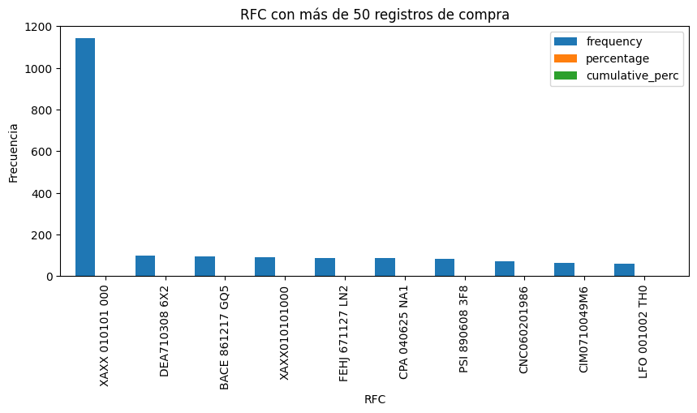

```python
#Gráfico de barras
Filtro_index.plot(kind = 'bar', width=1, figsize=(10,4))
plt.title('RFC con más de 50 registros de compra')
plt.xlabel('RFC')
plt.ylabel('Frecuencia')
```

```python
indices_lista = Filtro["RFC"].tolist()
indices_lista

resultados = df_clientes[df_clientes['RFC'].isin(indices_lista)]
resultados
```

|  | CLIENTE | RFC | NOMBRE |
| --- | --- | --- | --- |
| 187 | 644 | CNC060201986 | CLAVOS NACIONALES C.N |
| 407 | 1690 | XAXX010101000 | CLIENTE MOSTRADOR |
| 628 | 2385 | CIM0710049M6 | CARCOUSTICS INDUSTRIAL DE MEXICO |
| 2990 | 5926 | XAXX010101000 | PÚBLICO EN GENERAL |
| 3207 | 6143 | XAXX010101000 | STEELHEAD, INC |
| 4149 | 8039 | XAXX010101000 | MILACRON LLC |
| 4998 | 2385A | CIM0710049M6 | CARCOUSTICS INDUSTRIAL DE MEXICO |
| 5021 | N.I. | XAXX010101000 | DEPOSITOS NO IDENTIFICADOS |

### **Columna CAT_LB**

```python
#Análisis variado de la columna
table4= freq_tbl(df['CAT_LB'])
table4
```

|  | CAT_LB | frequency | percentage | cumulative_perc |
| --- | --- | --- | --- | --- |
| 0 | Q2\|MEAN | 2986 | 0.277716 | 0.277716 |
| 1 | Q2 | 2705 | 0.251581 | 0.529297 |
| 2 | Q1 | 2670 | 0.248326 | 0.777623 |
| 3 | MEAN\|MAX | 2391 | 0.222377 | 1.000000 |

```python
#Filtro de valores mayores al número seleccionado
Filtro= table4[table4['frequency']>1]
Filtro
```

|  | CAT_LB | frequency | percentage | cumulative_perc |
| --- | --- | --- | --- | --- |
| 0 | Q2\|MEAN | 2986 | 0.277716 | 0.277716 |
| 1 | Q2 | 2705 | 0.251581 | 0.529297 |
| 2 | Q1 | 2670 | 0.248326 | 0.777623 |
| 3 | MEAN\|MAX | 2391 | 0.222377 | 1.000000 |

```python
#Ajustar índice
Filtro_index= Filtro.set_index('CAT_LB')
Filtro_index
```

| CAT_LB | frequency | percentage | cumulative_perc |
| --- | --- | --- | --- |
| Q2\|MEAN | 2986 | 0.277716 | 0.277716 |
| Q2 | 2705 | 0.251581 | 0.529297 |
| Q1 | 2670 | 0.248326 | 0.777623 |
| MEAN\|MAX | 2391 | 0.222377 | 1.000000 |

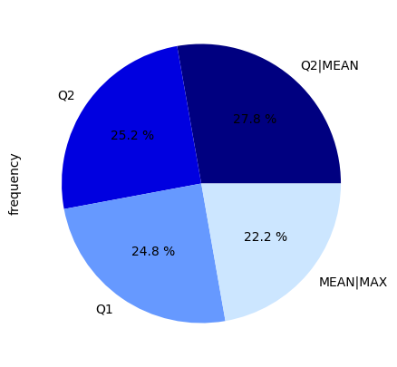

```python
#Gráfico de pastel
colors = ["#000080","#0000E0","#6699FF","#CCE6FF"]
Filtro_index["frequency"].plot(kind='pie', figsize=(20,5), shadow=False, autopct="%0.1f %%", colors=colors)
plt.show()
```

Esta columna fu creada en un proceso anterior, y muestra el conteo de los valores por cada categoría. Q1 significa que los valores se encuentran en el Cuartil 1, de la misma forma que Q2 muestra valores en el Cuartil 2. Q2|MEAN clasifica aquellos valores que se encuentran entre el límite superior de Q2 y el promedio y finalmente MEAN|MAX los valores que se encuentran arriba del promedio. Se puede observar que la categoría con mayor porcentaje es Q2|MEAN.

## **df_devoluciones**

Se eligieron las siguientes columnas categóricas: "CLIENTE","VENDEDOR","RFC","CAT_LB" porque representan una parte fundamental del análisis gráfico para mostrar su frecuencia y porcentaje. No se eligieron las columnas numéricas (a las que se analizó con estadística descriptiva) y tampoco se eligieron: CVE_DOC (debido a que es un índice único de documento de cada factura), TIP_DOC y las columnas con tipo de datp de fecha.

```python
filtro2 = df_devoluciones.loc[:,["CLIENTE","VENDEDOR","RFC","CAT_LB"]]
filtro2['VENDEDOR'] = filtro2['VENDEDOR'].replace(0, 'Sin registro')
```

```python
filtro2.isnull().sum()
```

```
CLIENTE     0
VENDEDOR    0
RFC         0
CAT_LB      0
dtype: int64
```

```python
df2=filtro2
```

### **Columna CLIENTE**

```python
#Análisis variado de la columna
table1= freq_tbl(df2['CLIENTE'])
table1
```

|  | CLIENTE | frequency | percentage | cumulative_perc |
| --- | --- | --- | --- | --- |
| 0 | 1852 | 13 | 0.069519 | 0.069519 |
| 1 | 6253 | 10 | 0.053476 | 0.122995 |
| 2 | 2768 | 5 | 0.026738 | 0.149733 |
| 3 | 3912 | 5 | 0.026738 | 0.176471 |
| 4 | 5644 | 5 | 0.026738 | 0.203209 |
| ... | ... | ... | ... | ... |
| 101 | 1289 | 1 | 0.005348 | 0.978610 |
| 102 | 455 | 1 | 0.005348 | 0.983957 |
| 103 | 7088 | 1 | 0.005348 | 0.989305 |
| 104 | 3836 | 1 | 0.005348 | 0.994652 |
| 105 | 4486 | 1 | 0.005348 | 1.000000 |

106 rows × 4 columns

```python
#Filtro de valores mayores al número seleccionado
Filtro= table1[table1['frequency']>2]
Filtro
```

|  | CLIENTE | frequency | percentage | cumulative_perc |
| --- | --- | --- | --- | --- |
| 0 | 1852 | 13 | 0.069519 | 0.069519 |
| 1 | 6253 | 10 | 0.053476 | 0.122995 |
| 2 | 2768 | 5 | 0.026738 | 0.149733 |
| 3 | 3912 | 5 | 0.026738 | 0.176471 |
| 4 | 5644 | 5 | 0.026738 | 0.203209 |
| 5 | 3228 | 5 | 0.026738 | 0.229947 |
| 6 | 1583 | 5 | 0.026738 | 0.256684 |
| 7 | 8503 | 5 | 0.026738 | 0.283422 |
| 8 | 253 | 4 | 0.021390 | 0.304813 |
| 9 | 537 | 3 | 0.016043 | 0.320856 |
| 10 | 2244 | 3 | 0.016043 | 0.336898 |
| 11 | 5926 | 3 | 0.016043 | 0.352941 |
| 12 | 2385 | 3 | 0.016043 | 0.368984 |
| 13 | 3930 | 3 | 0.016043 | 0.385027 |
| 14 | 161 | 3 | 0.016043 | 0.401070 |

```python
#Ajustar índice
Filtro_index= Filtro.set_index('CLIENTE')
Filtro_index
```

| CLIENTE | frequency | percentage | cumulative_perc |
| --- | --- | --- | --- |
| 1852 | 13 | 0.069519 | 0.069519 |
| 6253 | 10 | 0.053476 | 0.122995 |
| 2768 | 5 | 0.026738 | 0.149733 |
| 3912 | 5 | 0.026738 | 0.176471 |
| 5644 | 5 | 0.026738 | 0.203209 |
| 3228 | 5 | 0.026738 | 0.229947 |
| 1583 | 5 | 0.026738 | 0.256684 |
| 8503 | 5 | 0.026738 | 0.283422 |
| 253 | 4 | 0.021390 | 0.304813 |
| 537 | 3 | 0.016043 | 0.320856 |
| 2244 | 3 | 0.016043 | 0.336898 |
| 5926 | 3 | 0.016043 | 0.352941 |
| 2385 | 3 | 0.016043 | 0.368984 |
| 3930 | 3 | 0.016043 | 0.385027 |
| 161 | 3 | 0.016043 | 0.401070 |

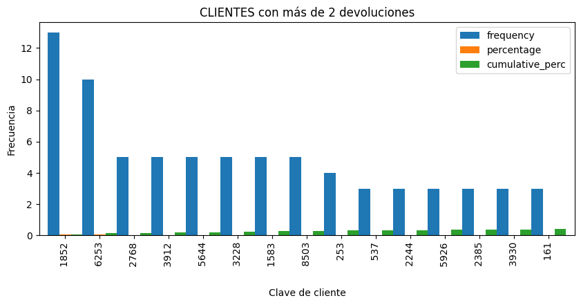

```python
#Gráfico de barras
Filtro_index.plot(kind = 'bar', width=1, figsize=(10,4))
plt.title('CLIENTES con más de 2 devoluciones')
plt.xlabel('Clave de cliente')
plt.ylabel('Frecuencia')
```

Se puede observar que la clave de cliente con más devoluciones es 1852 siendo ITW POLY MEX. A continuación se coteja con el df de clientes para identificar los nombres

```python
indices_lista = Filtro["CLIENTE"].tolist()
indices_lista

resultados = df_clientes[df_clientes['CLIENTE'].isin(indices_lista)]
resultados
```

|  | CLIENTE | RFC | NOMBRE |
| --- | --- | --- | --- |
| 60 | 161 | LFO001002TH0 | LBQ FOUNDRY |
| 95 | 253 | SME7811306Z7 | SIKA MEXICANA |
| 171 | 537 | MME960821JHA | MOLINERA DE MEXICO |
| 386 | 1583 | BPR860613QI5 | BETA PROCESOS |
| 446 | 1852 | IPM6203226B4 | ITW POLY MEX |
| 563 | 2244 | OBC9905057Y4 | OERLIKON BALZERS COATING MEXICO |
| 628 | 2385 | CIM0710049M6 | CARCOUSTICS INDUSTRIAL DE MEXICO |
| 784 | 2768 | CPA040625NA1 | CEREALES Y PASTAS |
| 1012 | 3228 | KLM970416U59 | KERN LIEBERS MEXICO |
| 1516 | 3912 | DPM960115H92 | DAYTON PROGRESS MEXICO |
| 1532 | 3930 | ILA8912077Z8 | INDUSTRIAS LANCERMEX |
| 2717 | 5644 | UFM030725814 | UNIQUE FABRICATING DE MEXICO |
| 2990 | 5926 | XAXX010101000 | PÚBLICO EN GENERAL |
| 3317 | 6253 | QSM1512154DA | Q SEALS DE MEXICO |
| 4604 | 8503 | EMP110817U86 | AIRBUS HELICOPTERS MEXICO QUERETARO |

### **Columna VENDEDOR**

```python
#Análisis variado de la columna
table2= freq_tbl(df2['VENDEDOR'])
table2
```

|  | VENDEDOR | frequency | percentage | cumulative_perc |
| --- | --- | --- | --- | --- |
| 0 | 2 | 59 | 0.315508 | 0.315508 |
| 1 | 1 | 41 | 0.219251 | 0.534759 |
| 2 | 3 | 32 | 0.171123 | 0.705882 |
| 3 | 5 | 21 | 0.112299 | 0.818182 |
| 4 | 6 | 19 | 0.101604 | 0.919786 |
| 5 | 4 | 12 | 0.064171 | 0.983957 |
| 6 | Sin registro | 3 | 0.016043 | 1.000000 |

```python
#Filtro de valores mayores al número seleccionado
Filtro= table2[table2['frequency']>1]
Filtro
```

|  | VENDEDOR | frequency | percentage | cumulative_perc |
| --- | --- | --- | --- | --- |
| 0 | 2 | 59 | 0.315508 | 0.315508 |
| 1 | 1 | 41 | 0.219251 | 0.534759 |
| 2 | 3 | 32 | 0.171123 | 0.705882 |
| 3 | 5 | 21 | 0.112299 | 0.818182 |
| 4 | 6 | 19 | 0.101604 | 0.919786 |
| 5 | 4 | 12 | 0.064171 | 0.983957 |
| 6 | Sin registro | 3 | 0.016043 | 1.000000 |

```python
#Ajustar índice
Filtro_index= Filtro.set_index('VENDEDOR')
Filtro_index
```

| VENDEDOR | frequency | percentage | cumulative_perc |
| --- | --- | --- | --- |
| 2 | 59 | 0.315508 | 0.315508 |
| 1 | 41 | 0.219251 | 0.534759 |
| 3 | 32 | 0.171123 | 0.705882 |
| 5 | 21 | 0.112299 | 0.818182 |
| 6 | 19 | 0.101604 | 0.919786 |
| 4 | 12 | 0.064171 | 0.983957 |
| Sin registro | 3 | 0.016043 | 1.000000 |

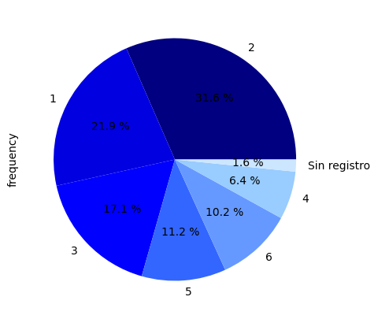

```python
#Gráfico de pastel
colors = ["#000080","#0000E0","#0000FF","#3366FF","#6699FF","#99CCFF","#CCE6FF"]
Filtro_index["frequency"].plot(kind='pie', figsize=(20,5), shadow=False, autopct="%0.1f %%", colors=colors)
plt.show()
```

### **Columna RFC**

```python
#Análisis variado de la columna
table3= freq_tbl(df2['RFC'])
table3
```

|  | RFC | frequency | percentage | cumulative_perc |
| --- | --- | --- | --- | --- |
| 0 | IPM-620322-6B4 | 13 | 0.069519 | 0.069519 |
| 1 | QSM 151215 4DA | 10 | 0.053476 | 0.122995 |
| 2 | CPA040625NA1 | 5 | 0.026738 | 0.149733 |
| 3 | EMP110817U86 | 5 | 0.026738 | 0.176471 |
| 4 | UFM 030725 814 | 5 | 0.026738 | 0.203209 |
| ... | ... | ... | ... | ... |
| 106 | FSO160930AA2 | 1 | 0.005348 | 0.978610 |
| 107 | CRI 080722 NR2 | 1 | 0.005348 | 0.983957 |
| 108 | FNG-991014-C66 | 1 | 0.005348 | 0.989305 |
| 109 | MFB 950202 DS7 | 1 | 0.005348 | 0.994652 |
| 110 | INE 911127 JG1 | 1 | 0.005348 | 1.000000 |

111 rows × 4 columns

```python
#Filtro de valores mayores al número seleccionado
Filtro= table3[table3['frequency']>2]
Filtro
```

|  | RFC | frequency | percentage | cumulative_perc |
| --- | --- | --- | --- | --- |
| 0 | IPM-620322-6B4 | 13 | 0.069519 | 0.069519 |
| 1 | QSM 151215 4DA | 10 | 0.053476 | 0.122995 |
| 2 | CPA040625NA1 | 5 | 0.026738 | 0.149733 |
| 3 | EMP110817U86 | 5 | 0.026738 | 0.176471 |
| 4 | UFM 030725 814 | 5 | 0.026738 | 0.203209 |
| 5 | BPR-860613-QI5 | 5 | 0.026738 | 0.229947 |
| 6 | KLM970416U59 | 5 | 0.026738 | 0.256684 |
| 7 | DPM 960115 H92 | 5 | 0.026738 | 0.283422 |
| 8 | SME 781130 6Z7 | 3 | 0.016043 | 0.299465 |
| 9 | CIM0710049M6 | 3 | 0.016043 | 0.315508 |
| 10 | XAXX 010101 000 | 3 | 0.016043 | 0.331551 |
| 11 | ILA-891207-7Z8 | 3 | 0.016043 | 0.347594 |
| 12 | OBC 990505 7Y4 | 3 | 0.016043 | 0.363636 |

```python
#Ajustar índice
Filtro_index= Filtro.set_index('RFC')
Filtro_index
```

| RFC | frequency | percentage | cumulative_perc |
| --- | --- | --- | --- |
| IPM-620322-6B4 | 13 | 0.069519 | 0.069519 |
| QSM 151215 4DA | 10 | 0.053476 | 0.122995 |
| CPA040625NA1 | 5 | 0.026738 | 0.149733 |
| EMP110817U86 | 5 | 0.026738 | 0.176471 |
| UFM 030725 814 | 5 | 0.026738 | 0.203209 |
| BPR-860613-QI5 | 5 | 0.026738 | 0.229947 |
| KLM970416U59 | 5 | 0.026738 | 0.256684 |
| DPM 960115 H92 | 5 | 0.026738 | 0.283422 |
| SME 781130 6Z7 | 3 | 0.016043 | 0.299465 |
| CIM0710049M6 | 3 | 0.016043 | 0.315508 |
| XAXX 010101 000 | 3 | 0.016043 | 0.331551 |
| ILA-891207-7Z8 | 3 | 0.016043 | 0.347594 |
| OBC 990505 7Y4 | 3 | 0.016043 | 0.363636 |

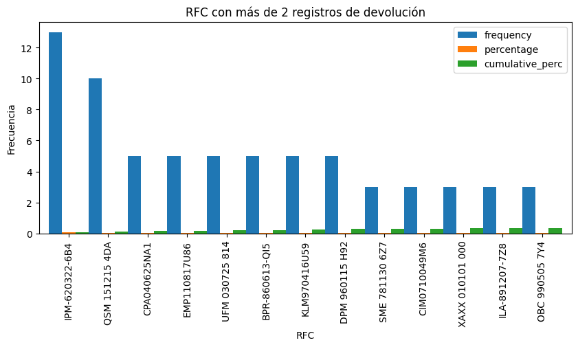

```python
#Gráfico de barras
Filtro_index.plot(kind = 'bar', width=1, figsize=(10,4))
plt.title('RFC con más de 2 registros de devolución')
plt.xlabel('RFC')
plt.ylabel('Frecuencia')
```

```python
indices_lista = Filtro["RFC"].tolist()
indices_lista

resultados = df_clientes[df_clientes['RFC'].isin(indices_lista)]
resultados
```

|  | CLIENTE | RFC | NOMBRE |
| --- | --- | --- | --- |
| 628 | 2385 | CIM0710049M6 | CARCOUSTICS INDUSTRIAL DE MEXICO |
| 784 | 2768 | CPA040625NA1 | CEREALES Y PASTAS |
| 1012 | 3228 | KLM970416U59 | KERN LIEBERS MEXICO |
| 3559 | 6496 | QSM 151215 4DA | Q SEALS DE MEXICO, S. DE R.L. DE C.V. |
| 4604 | 8503 | EMP110817U86 | AIRBUS HELICOPTERS MEXICO QUERETARO |
| 4998 | 2385A | CIM0710049M6 | CARCOUSTICS INDUSTRIAL DE MEXICO |

### **Columna CAT_LB**

```python
#Análisis variado de la columna
table4= freq_tbl(df2['CAT_LB'])
table4
```

|  | CAT_LB | frequency | percentage | cumulative_perc |
| --- | --- | --- | --- | --- |
| 0 | <MEAN | 129 | 0.68984 | 0.68984 |
| 1 | >MEAN | 58 | 0.31016 | 1.00000 |

```python
#Filtro de valores mayores al número seleccionado
Filtro= table4[table4['frequency']>1]
Filtro
```

|  | CAT_LB | frequency | percentage | cumulative_perc |
| --- | --- | --- | --- | --- |
| 0 | <MEAN | 129 | 0.68984 | 0.68984 |
| 1 | >MEAN | 58 | 0.31016 | 1.00000 |

```python
#Ajustar índice
Filtro_index= Filtro.set_index('CAT_LB')
Filtro_index
```

| CAT_LB | frequency | percentage | cumulative_perc |
| --- | --- | --- | --- |
| <MEAN | 129 | 0.68984 | 0.68984 |
| >MEAN | 58 | 0.31016 | 1.00000 |

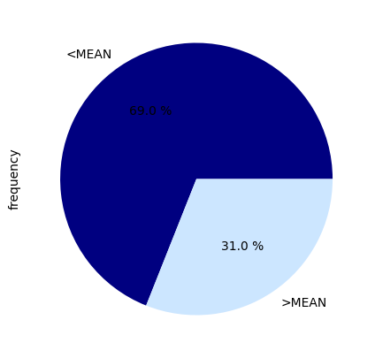

```python
#Gráfico de pastel
colors = ["#000080","#CCE6FF"]
Filtro_index["frequency"].plot(kind='pie', figsize=(20,5), shadow=False, autopct="%0.1f %%", colors=colors)
plt.show()
```

Esta columna fue creada en un proceso anterior, y muestra el conteo de los valores por cada categoría. < Mean clasifia los valores menores al promedio mientras que > MEAN muestra los que están por encima. Se puede observar que hay muchos más valores de devoluciones por debajo del promedio, por lo que hay devoluciones con montos elevados dispersas.

## **df_notascredito**

Se eligieron las siguientes columnas categóricas: "CLIENTE","VENDEDOR","RFC","QCUT" porque representan una parte fundamental del análisis gráfico para mostrar su frecuencia y porcentaje. No se eligieron las columnas numéricas (a las que se analizó con estadística descriptiva) y tampoco se eligieron: CVE_NC (debido a que es un índice único de documento de cada factura), TIP_OP y las columnas con tipo de dato de fecha.

```python
filtro3 = df_notascredito.loc[:,["CLIENTE","VENDEDOR","RFC","QCUT"]]
filtro3["CLIENTE"] = filtro3["CLIENTE"].astype(str)
filtro3['VENDEDOR'] = filtro3['VENDEDOR'].replace(0, 'Sin registro')
```

```python
filtro3.isnull().sum()
```

```
CLIENTE     0
VENDEDOR    0
RFC         0
QCUT        0
dtype: int64
```

```python
df3=filtro3
```

### **Columna CLIENTE**

```python
#Análisis variado de la columna
table1= freq_tbl(df3['CLIENTE'])
table1
```

|  | CLIENTE | frequency | percentage | cumulative_perc |
| --- | --- | --- | --- | --- |
| 0 | 5926 | 107 | 0.214859 | 0.214859 |
| 1 | 209 | 5 | 0.010040 | 0.224900 |
| 2 | 2357 | 4 | 0.008032 | 0.232932 |
| 3 | 5982 | 4 | 0.008032 | 0.240964 |
| 4 | 6839 | 4 | 0.008032 | 0.248996 |
| ... | ... | ... | ... | ... |
| 293 | 8162 | 1 | 0.002008 | 0.991968 |
| 294 | 8125 | 1 | 0.002008 | 0.993976 |
| 295 | 2995 | 1 | 0.002008 | 0.995984 |
| 296 | 3230 | 1 | 0.002008 | 0.997992 |
| 297 | 8842 | 1 | 0.002008 | 1.000000 |

298 rows × 4 columns

```python
#Filtro de valores mayores al número seleccionado
Filtro= table1[table1['frequency']>2]
Filtro
```

|  | CLIENTE | frequency | percentage | cumulative_perc |
| --- | --- | --- | --- | --- |
| 0 | 5926 | 107 | 0.214859 | 0.214859 |
| 1 | 209 | 5 | 0.010040 | 0.224900 |
| 2 | 2357 | 4 | 0.008032 | 0.232932 |
| 3 | 5982 | 4 | 0.008032 | 0.240964 |
| 4 | 6839 | 4 | 0.008032 | 0.248996 |
| 5 | 3610 | 4 | 0.008032 | 0.257028 |
| 6 | 4527 | 4 | 0.008032 | 0.265060 |
| 7 | 6059 | 3 | 0.006024 | 0.271084 |
| 8 | 2029 | 3 | 0.006024 | 0.277108 |
| 9 | 6354 | 3 | 0.006024 | 0.283133 |
| 10 | 6978 | 3 | 0.006024 | 0.289157 |
| 11 | 4581 | 3 | 0.006024 | 0.295181 |
| 12 | 5923 | 3 | 0.006024 | 0.301205 |
| 13 | 4843 | 3 | 0.006024 | 0.307229 |
| 14 | 6053 | 3 | 0.006024 | 0.313253 |
| 15 | 1943 | 3 | 0.006024 | 0.319277 |
| 16 | 3937 | 3 | 0.006024 | 0.325301 |
| 17 | 5598 | 3 | 0.006024 | 0.331325 |
| 18 | 6278 | 3 | 0.006024 | 0.337349 |
| 19 | 4563 | 3 | 0.006024 | 0.343373 |
| 20 | 3806 | 3 | 0.006024 | 0.349398 |

```python
#Ajustar índice
Filtro_index= Filtro.set_index('CLIENTE')
Filtro_index
```

| CLIENTE | frequency | percentage | cumulative_perc |
| --- | --- | --- | --- |
| 5926 | 107 | 0.214859 | 0.214859 |
| 209 | 5 | 0.010040 | 0.224900 |
| 2357 | 4 | 0.008032 | 0.232932 |
| 5982 | 4 | 0.008032 | 0.240964 |
| 6839 | 4 | 0.008032 | 0.248996 |
| 3610 | 4 | 0.008032 | 0.257028 |
| 4527 | 4 | 0.008032 | 0.265060 |
| 6059 | 3 | 0.006024 | 0.271084 |
| 2029 | 3 | 0.006024 | 0.277108 |
| 6354 | 3 | 0.006024 | 0.283133 |
| 6978 | 3 | 0.006024 | 0.289157 |
| 4581 | 3 | 0.006024 | 0.295181 |
| 5923 | 3 | 0.006024 | 0.301205 |
| 4843 | 3 | 0.006024 | 0.307229 |
| 6053 | 3 | 0.006024 | 0.313253 |
| 1943 | 3 | 0.006024 | 0.319277 |
| 3937 | 3 | 0.006024 | 0.325301 |
| 5598 | 3 | 0.006024 | 0.331325 |
| 6278 | 3 | 0.006024 | 0.337349 |
| 4563 | 3 | 0.006024 | 0.343373 |
| 3806 | 3 | 0.006024 | 0.349398 |

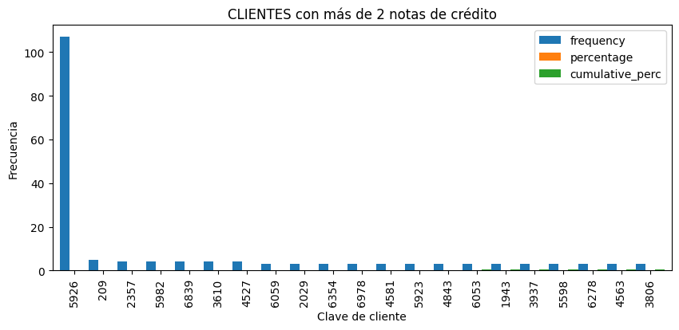

```python
#Gráfico de barras
Filtro_index.plot(kind = 'bar', width=1, figsize=(10,4))
plt.title('CLIENTES con más de 2 notas de crédito')
plt.xlabel('Clave de cliente')
plt.ylabel('Frecuencia')
```

### **Columna VENDEDOR**

```python
#Análisis variado de la columna
table2= freq_tbl(df3['VENDEDOR'])
table2
```

|  | VENDEDOR | frequency | percentage | cumulative_perc |
| --- | --- | --- | --- | --- |
| 0 | 2 | 360 | 0.722892 | 0.722892 |
| 1 | 3 | 50 | 0.100402 | 0.823293 |
| 2 | 1 | 21 | 0.042169 | 0.865462 |
| 3 | 5 | 20 | 0.040161 | 0.905622 |
| 4 | 6 | 18 | 0.036145 | 0.941767 |
| 5 | 4 | 17 | 0.034137 | 0.975904 |
| 6 | Sin registro | 10 | 0.020080 | 0.995984 |
| 7 | 7 | 1 | 0.002008 | 0.997992 |
| 8 | 12 | 1 | 0.002008 | 1.000000 |

```python
#Filtro de valores mayores al número seleccionado
Filtro= table2[table2['frequency']>1]
Filtro
```

|  | VENDEDOR | frequency | percentage | cumulative_perc |
| --- | --- | --- | --- | --- |
| 0 | 2 | 360 | 0.722892 | 0.722892 |
| 1 | 3 | 50 | 0.100402 | 0.823293 |
| 2 | 1 | 21 | 0.042169 | 0.865462 |
| 3 | 5 | 20 | 0.040161 | 0.905622 |
| 4 | 6 | 18 | 0.036145 | 0.941767 |
| 5 | 4 | 17 | 0.034137 | 0.975904 |
| 6 | Sin registro | 10 | 0.020080 | 0.995984 |

```python
#Ajustar índice
Filtro_index= Filtro.set_index('VENDEDOR')
Filtro_index
```

| VENDEDOR | frequency | percentage | cumulative_perc |
| --- | --- | --- | --- |
| 2 | 360 | 0.722892 | 0.722892 |
| 3 | 50 | 0.100402 | 0.823293 |
| 1 | 21 | 0.042169 | 0.865462 |
| 5 | 20 | 0.040161 | 0.905622 |
| 6 | 18 | 0.036145 | 0.941767 |
| 4 | 17 | 0.034137 | 0.975904 |
| Sin registro | 10 | 0.020080 | 0.995984 |

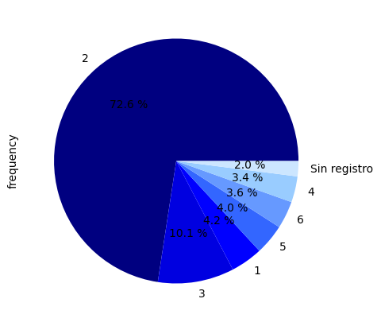

```python
#Gráfico de pastel
colors = ["#000080","#0000E0","#0000FF","#3366FF","#6699FF","#99CCFF","#CCE6FF"]
Filtro_index["frequency"].plot(kind='pie', figsize=(20,5), shadow=False, autopct="%0.1f %%", colors=colors)
plt.show()
```

### **Columna RFC**

```python
#Análisis variado de la columna
table3= freq_tbl(df3['RFC'])
table3
```

|  | RFC | frequency | percentage | cumulative_perc |
| --- | --- | --- | --- | --- |
| 0 | XAXX 010101 000 | 98 | 0.196787 | 0.196787 |
| 1 | XAXX010101000 | 9 | 0.018072 | 0.214859 |
| 2 | IEA-930426-5N2 | 5 | 0.010040 | 0.224900 |
| 3 | CLS0705293G1 | 4 | 0.008032 | 0.232932 |
| 4 | QME061019HR7 | 4 | 0.008032 | 0.240964 |
| ... | ... | ... | ... | ... |
| 295 | MME160610P57 | 1 | 0.002008 | 0.991968 |
| 296 | FDG-960314-1I6 | 1 | 0.002008 | 0.993976 |
| 297 | WAP-091030-5W8 | 1 | 0.002008 | 0.995984 |
| 298 | GOAE830429CF0 | 1 | 0.002008 | 0.997992 |
| 299 | MAMN580503DK3 | 1 | 0.002008 | 1.000000 |

300 rows × 4 columns

```python
#Filtro de valores mayores al número seleccionado
Filtro= table3[table3['frequency']>3]
Filtro
```

|  | RFC | frequency | percentage | cumulative_perc |
| --- | --- | --- | --- | --- |
| 0 | XAXX 010101 000 | 98 | 0.196787 | 0.196787 |
| 1 | XAXX010101000 | 9 | 0.018072 | 0.214859 |
| 2 | IEA-930426-5N2 | 5 | 0.010040 | 0.224900 |
| 3 | CLS0705293G1 | 4 | 0.008032 | 0.232932 |
| 4 | QME061019HR7 | 4 | 0.008032 | 0.240964 |
| 5 | ALK180903DT6 | 4 | 0.008032 | 0.248996 |
| 6 | HEPJ 850119 PC7 | 4 | 0.008032 | 0.257028 |
| 7 | TLU170616JU8 | 4 | 0.008032 | 0.265060 |

```python
#Ajustar índice
Filtro_index= Filtro.set_index('RFC')
Filtro_index
```

| RFC | frequency | percentage | cumulative_perc |
| --- | --- | --- | --- |
| XAXX 010101 000 | 98 | 0.196787 | 0.196787 |
| XAXX010101000 | 9 | 0.018072 | 0.214859 |
| IEA-930426-5N2 | 5 | 0.010040 | 0.224900 |
| CLS0705293G1 | 4 | 0.008032 | 0.232932 |
| QME061019HR7 | 4 | 0.008032 | 0.240964 |
| ALK180903DT6 | 4 | 0.008032 | 0.248996 |
| HEPJ 850119 PC7 | 4 | 0.008032 | 0.257028 |
| TLU170616JU8 | 4 | 0.008032 | 0.265060 |

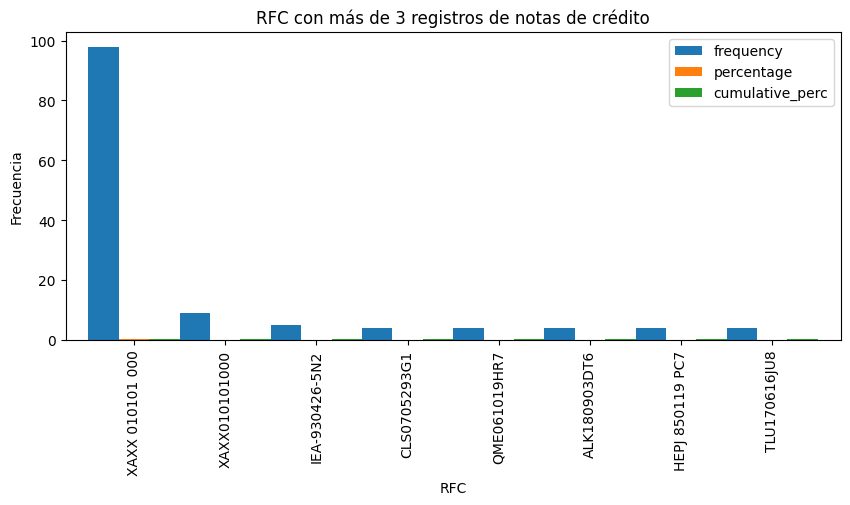

```python
#Gráfico de barras
Filtro_index.plot(kind = 'bar', width=1, figsize=(10,4))
plt.title('RFC con más de 3 registros de notas de crédito')
plt.xlabel('RFC')
plt.ylabel('Frecuencia')
```

```python
#Análisis variado de la columna
table4= freq_tbl(df3['QCUT'])
table4
```

|  | QCUT | frequency | percentage | cumulative_perc |
| --- | --- | --- | --- | --- |
| 0 | Q1 | 125 | 0.251004 | 0.251004 |
| 1 | Q4 | 125 | 0.251004 | 0.502008 |
| 2 | Q2 | 124 | 0.248996 | 0.751004 |
| 3 | Q3 | 124 | 0.248996 | 1.000000 |

```python
#Filtro de valores mayores al número seleccionado
Filtro= table4[table4['frequency']>1]
Filtro
```

|  | QCUT | frequency | percentage | cumulative_perc |
| --- | --- | --- | --- | --- |
| 0 | Q1 | 125 | 0.251004 | 0.251004 |
| 1 | Q4 | 125 | 0.251004 | 0.502008 |
| 2 | Q2 | 124 | 0.248996 | 0.751004 |
| 3 | Q3 | 124 | 0.248996 | 1.000000 |

```python
#Ajustar índice
Filtro_index= Filtro.set_index('QCUT')
Filtro_index
```

| QCUT | frequency | percentage | cumulative_perc |
| --- | --- | --- | --- |
| Q1 | 125 | 0.251004 | 0.251004 |
| Q4 | 125 | 0.251004 | 0.502008 |
| Q2 | 124 | 0.248996 | 0.751004 |
| Q3 | 124 | 0.248996 | 1.000000 |

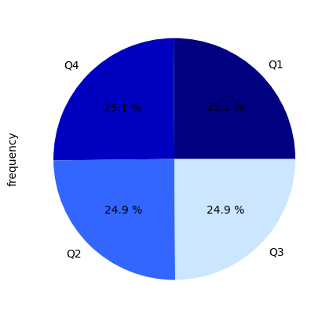

```python
#Gráfico de pastel
colors = ["#000080","#0000C0","#3366FF","#CCE6FF"]
Filtro_index["frequency"].plot(kind='pie', figsize=(20,5), shadow=False, autopct="%0.1f %%", colors=colors)
plt.show()
```

# **Determinación de conjuntos**

## **df_facturacion**

Para la modelación se decidió utilizar el dataframe de facturación, debido a que es el que tiene los datos más relevantes para el análisis.Las variables que se decidieron utilizar para evaluarlo son las siguientes:

**Modelación lineal:**

- Modelo 1:
  - Variable dependiente: "Total"
  - Variable independiente: "DES_TOT"
- Modelo 2:
  - Variable dependiente: "Total"
  - Variable independiente: "CAN_TOT"
- Modelo 3:
  - Variable dependiente: "Total"
  - Variable independiente: "VENDEDOR"

Estas elecciones se basaron también en el análisis de la gráfica de emparejamiento entre variables

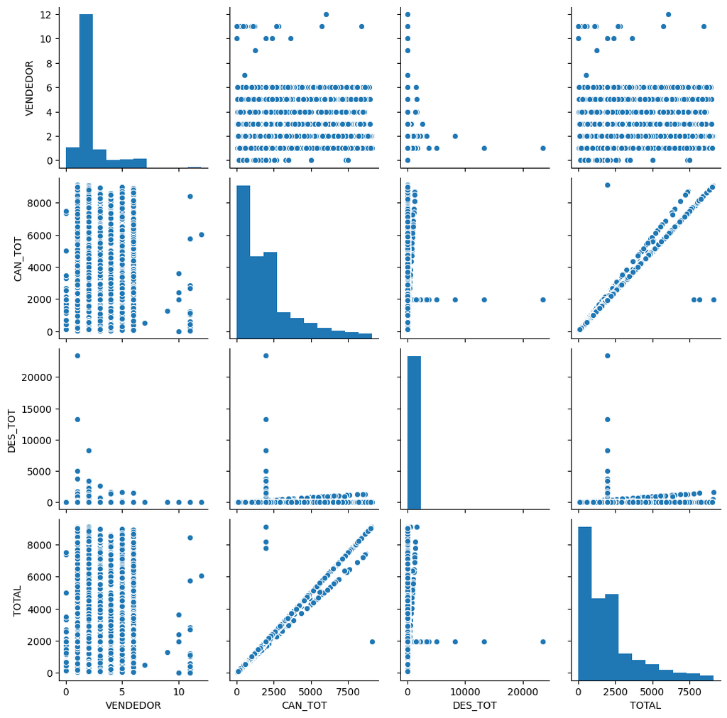

```python
sns.pairplot(df_facturacion)
```

**Modelación no lineal:**

Para la modelación no lineal se escogío analizar las columnas de Total y DES_TOT, conviertiendo la variable de DES_TOT a una dicotómica para el análisis logístico.

# **Modelización lineal**

## **TOTAL vs DES_TOT**

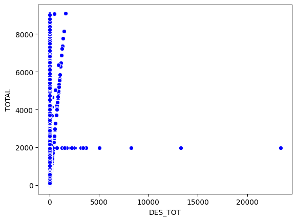

```python
from turtle import color

sns.scatterplot(x='DES_TOT', y='TOTAL', color="blue", data=df_facturacion)
```

```python
#Declaramos las variables dependientes e independientes para la regresión lineal
Vars_Indep= df_facturacion[['DES_TOT']]
Var_Dep= df_facturacion['TOTAL']
```

```python
#Se define model como la función de regresión lineal
from sklearn.linear_model import LinearRegression
model= LinearRegression()
```

```python
#Verificamos la función relacionada al modelo
type(model)
```

```
sklearn.linear_model._base.LinearRegression
```

```python
#Ajustamos el modelo con las variables antes declaradas
model.fit(X=Vars_Indep, y=Var_Dep)
```

```
LinearRegression()
```

```python
#Verificamos los coeficientes obtenidos para el modelo ajustado
model.__dict__
```

```
{'fit_intercept': True,
 'copy_X': True,
 'n_jobs': None,
 'positive': False,
 'feature_names_in_': array(['DES_TOT'], dtype=object),
 'n_features_in_': 1,
 'coef_': array([0.06017609]),
 'rank_': 1,
 'singular_': array([45211.47612917]),
 'intercept_': 1963.7164930323581}
```

```python
#Evaluamos la eficiencia del modelo obtenido por medio del coeficiente R Determinación
model.score(Vars_Indep,Var_Dep)
```

```
0.00019315819492893294
```

```python
#Corroboramos cual es el coeficiente de Determinación de nuestro modelo
coef_Deter=model.score(X=Vars_Indep, y=Var_Dep)
coef_Deter
```

```
0.00019315819492893294
```

```python
#Corroboramos cual es el coeficiente de Correlación de nuestro modelo
coef_Correl=np.sqrt(coef_Deter)
coef_Correl
```

```
0.013898136383304524
```

## **TOTAL vs CAN_TOT**

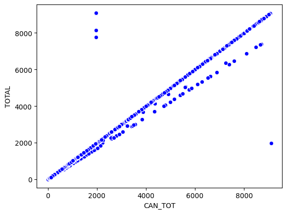

```python
from turtle import color

sns.scatterplot(x='CAN_TOT', y='TOTAL', color="blue", data=df_facturacion)
```

```python
#Declaramos las variables dependientes e independientes para la regresión lineal
Vars_Indep= df_facturacion[['CAN_TOT']]
Var_Dep= df_facturacion['TOTAL']
```

```python
#Se define model como la función de regresión lineal
from sklearn.linear_model import LinearRegression
model= LinearRegression()
```

```python
#Verificamos la función relacionada al modelo
type(model)
```

```
sklearn.linear_model._base.LinearRegression
```

```python
#Ajustamos el modelo con las variables antes declaradas
model.fit(X=Vars_Indep, y=Var_Dep)
```

```
LinearRegression()
```

```python
#Verificamos los coeficientes obtenidos para el modelo ajustado
model.__dict__
```

```
{'fit_intercept': True,
 'copy_X': True,
 'n_jobs': None,
 'positive': False,
 'feature_names_in_': array(['CAN_TOT'], dtype=object),
 'n_features_in_': 1,
 'coef_': array([0.99317284]),
 'rank_': 1,
 'singular_': array([196097.09750349]),
 'intercept_': 10.3445709619034}
```

```python
#Evaluamos la eficiencia del modelo obtenido por medio del coeficiente R Determinación
model.score(Vars_Indep,Var_Dep)
```

```
0.9898281966072057
```

```python
#Corroboramos cual es el coeficiente de Determinación de nuestro modelo
coef_Deter=model.score(X=Vars_Indep, y=Var_Dep)
coef_Deter
```

```
0.9898281966072057
```

```python
#Corroboramos cual es el coeficiente de Correlación de nuestro modelo
coef_Correl=np.sqrt(coef_Deter)
coef_Correl
```

```
0.994901098907427
```

**Interpretación**

Se comprueba la hipotesis de que ambas columnas estan estrechamente relacionadas, ya que una muestra el subtotal y la otra el total final de la factura. A partir de este análisis se puede inferir que la empresa Calor y Control realiza pocos descuentos y que de hecho los descuentos que realiza no impactan de forma negativa al monto de su facturacion, debido a que el porcentaje de correlación entre ambas columnas es muy elevado.

## **TOTAL vs VENDEDOR**

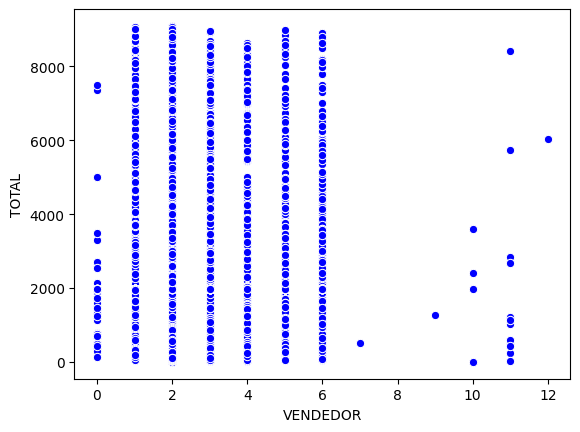

```python
from turtle import color

sns.scatterplot(x='VENDEDOR', y='TOTAL', color="blue", data=df_facturacion)
```

```python
#Declaramos las variables dependientes e independientes para la regresión lineal
Vars_Indep= df_facturacion[['VENDEDOR']]
Var_Dep= df_facturacion['TOTAL']
```

```python
#Se define model como la función de regresión lineal
from sklearn.linear_model import LinearRegression
model= LinearRegression()
```

```python
#Verificamos la función relacionada al modelo
type(model)
```

```
sklearn.linear_model._base.LinearRegression
```

```python
#Ajustamos el modelo con las variables antes declaradas
model.fit(X=Vars_Indep, y=Var_Dep)
```

```
LinearRegression()
```

```python
#Verificamos los coeficientes obtenidos para el modelo ajustado
model.__dict__
```

```
{'fit_intercept': True,
 'copy_X': True,
 'n_jobs': None,
 'positive': False,
 'feature_names_in_': array(['VENDEDOR'], dtype=object),
 'n_features_in_': 1,
 'coef_': array([153.58057227]),
 'rank_': 1,
 'singular_': array([120.86562171]),
 'intercept_': 1603.1797692705818}
```

```python
#Evaluamos la eficiencia del modelo obtenido por medio del coeficiente R Determinación
model.score(Vars_Indep,Var_Dep)
```

```
0.008991786046757988
```

```python
#Corroboramos cual es el coeficiente de Determinación de nuestro modelo
coef_Deter=model.score(X=Vars_Indep, y=Var_Dep)
coef_Deter
```

```
0.008991786046757988
```

```python
#Corroboramos cual es el coeficiente de Correlación de nuestro modelo
coef_Correl=np.sqrt(coef_Deter)
coef_Correl
```

```
0.09482502858822658
```

## **TOTAL vs VENDEDOR & CAN_TOT**

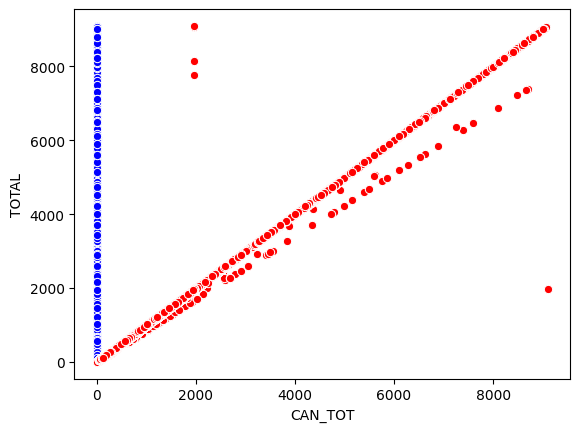

```python
from turtle import color
sns.scatterplot(x='VENDEDOR', y='TOTAL', color="blue", data=df_facturacion)
sns.scatterplot(x='CAN_TOT', y='TOTAL', color="red", data=df_facturacion)
```

```python
#Primer modelo Casas y Departamentos Enteros
Vars_Indep= df_facturacion[["VENDEDOR","CAN_TOT"]]
Var_Dep= df_facturacion['TOTAL']
from sklearn.linear_model import LinearRegression
model= LinearRegression()
model.fit(X=Vars_Indep, y=Var_Dep)
det1 = model.score(Vars_Indep,Var_Dep)
cor1 = np.sqrt(model.score(Vars_Indep,Var_Dep))
print('Coeficiente de Determinación: ',det1)
print('Coeficiente de Correlación: ',cor1)
model.__dict__
```

```
Coeficiente de Determinación:  0.9898302065966539
Coeficiente de Correlación:  0.9949021090522695
```

```
{'fit_intercept': True,
 'copy_X': True,
 'n_jobs': None,
 'positive': False,
 'feature_names_in_': array(['VENDEDOR', 'CAN_TOT'], dtype=object),
 'n_features_in_': 2,
 'coef_': array([2.30639132, 0.99303937]),
 'rank_': 2,
 'singular_': array([1.96097098e+05, 1.20331681e+02]),
 'intercept_': 5.176743138082202}
```

# **Modelización no lineal (Logaritmica)**

```python
#Declaramos las variables dependientes e independientes para la regresión No lineal
Vars_Indep= df_facturacion[['DES_TOT']]
Var_Dep= df_facturacion['TOTAL']
```

```python
#Redefinimos las variables
x= Vars_Indep
y= Var_Dep
```

```python
#sns.pairplot(df_facturacion)
```

```python
def func2(x, ln_a, b, c):
    return ln_a + b*x + np.log(np.abs(c - x))
```

```python
#Ajustamos los parámetros de la función curve_fit
from scipy.optimize import curve_fit
parametros2, covs2= curve_fit(func2, df_facturacion['DES_TOT'], df_facturacion['TOTAL'])
```

```python
#Obtenemos los coeficientes del modelo de regresión no lineal
parametros2
```

```
array([4.41719119e+03, 5.24055250e+00, 1.32902801e+04])
```

```python
#Creamos el modelo de predicción con los parámetros obtenidos
parametros2, _ = curve_fit(func2, df_facturacion['DES_TOT'], df_facturacion['TOTAL'])
ln_a2, b2, c2 = parametros2[ 0 ], parametros2[ 1 ], parametros2[ 2 ]
yfit2 = ln_a2 +b2*x + np.log(np.abs(c2 - x))
```

```python
#Calculamos las predicciones y reestructuramos el vector de predicciones
#yfit2 = yfit2.reshape(51, 1)
yfit2
```

|  | DES_TOT |
| --- | --- |
| 0 | 4426.68598 |
| 1 | 4426.68598 |
| 2 | 4426.68598 |
| 3 | 4426.68598 |
| 4 | 4426.68598 |
| ... | ... |
| 10747 | 4426.68598 |
| 10748 | 4426.68598 |
| 10749 | 4426.68598 |
| 10750 | 4426.68598 |
| 10751 | 4426.68598 |

10752 rows × 1 columns

[figure not shown]

```python
#Graficamos las predicciones y los datos originales para realizar la comparación
plt.plot(x, y, 'bo', label="y-original")
plt.plot(x, yfit2, label="a*exp(x*b)+c")
plt.xlabel('x')
plt.ylabel('y')
plt.legend(loc='best', fancybox=True, shadow=True)
plt.grid(True)
plt.show()
```

```python
#Calculamos el coeficiente de determinación del modelo
from sklearn.metrics import r2_score
R2 = r2_score(y, yfit2)
R2
```

```
0.03768838648763051
```

### **Comprobación predicciones vs original**

```python
#pd.set_option('display.max_rows', None)
df_facturacion.insert(0, 'Predicciones', yfit2)
df_facturacion[['Predicciones', 'TOTAL']]
```

|  | Predicciones | TOTAL |
| --- | --- | --- |
| 0 | 4426.68598 | 3980.000 |
| 1 | 4426.68598 | 1550.000 |
| 2 | 4426.68598 | 2435.440 |
| 3 | 4426.68598 | 3979.998 |
| 4 | 4426.68598 | 402.590 |
| ... | ... | ... |
| 10747 | 4426.68598 | 2178.000 |
| 10748 | 4426.68598 | 607.250 |
| 10749 | 4426.68598 | 567.757 |
| 10750 | 4426.68598 | 1944.950 |
| 10751 | 4426.68598 | 6813.000 |

10752 rows × 2 columns

# **Modelización no lineal (Logística)**

```python
#Cargamos librerias
import pandas as pd
import numpy as np
import matplotlib.pyplot as plt
import scipy.special as special
from scipy.optimize import curve_fit
import seaborn as sns
from sklearn.metrics import r2_score
from sklearn.model_selection import train_test_split
from sklearn.preprocessing import StandardScaler
```

```python
df_fac_log=df_facturacion.copy()
```

```python
df_fac_log.loc[df_fac_log['DES_TOT'] == 0, 'DES_TOT'] = 'SIN DESCUENTO'
df_fac_log.loc[df_fac_log['DES_TOT'] != 'SIN DESCUENTO', 'DES_TOT'] = 'CON DESCUENTO'
df_fac_log["DES_TOT"].value_counts()
```

```
SIN DESCUENTO    10605
CON DESCUENTO      147
Name: DES_TOT, dtype: int64
```

```python
#Declaramos las variables dependientes e independientes para la regresión Logística
Vars_Indep= df_fac_log[['TOTAL']]
Var_Dep= df_fac_log['DES_TOT']
```

```python
#Redefinimos las variables
X= Vars_Indep
y= Var_Dep
```

```python
#Dividimos el conjunto de datos en la parte de entrenamiento y prueba:
X_train, X_test, y_train, y_test = train_test_split(X, y, test_size=0.3, random_state = None)
```

```python
#Se escalan todos los datos
escalar = StandardScaler()

#Para realizar el escalamiento de las variables “X” tanto de entrenamiento como de prueba, utilizaremos fit_transform
X_train = escalar.fit_transform(X_train)
X_test = escalar.transform(X_test)

#Definimos el algoritmo a utilizar
from sklearn.linear_model import LogisticRegression
algoritmo = LogisticRegression()

#Entrenamos el modelo
algoritmo.fit(X_train, y_train)

#Realizamos una predicción
y_pred = algoritmo.predict(X_test)
y_pred
```

```
array(['SIN DESCUENTO', 'SIN DESCUENTO', 'SIN DESCUENTO', ...,
       'SIN DESCUENTO', 'SIN DESCUENTO', 'SIN DESCUENTO'], dtype=object)
```

```python
#Verifico la matriz de Confusión
from sklearn.metrics import confusion_matrix
matriz = confusion_matrix(y_test, y_pred)
print('Matriz de Confusión:')
print(matriz)
```

```
Matriz de Confusión:
[[   0   51]
 [   0 3175]]
```

```python
#Calculo la precisión del modelo
from sklearn.metrics import precision_score

precision = precision_score(y_test, y_pred, average="binary", pos_label="CON DESCUENTO")
print('Precisión del modelo:')
print(precision)
```

```
Precisión del modelo:
0.0
```

```python
#Calculo la exactitud del modelo
from sklearn.metrics import accuracy_score

exactitud = accuracy_score(y_test, y_pred)
print('Exactitud del modelo:')
print(exactitud)
```

```
Exactitud del modelo:
0.9841909485430874
```

```python
#Calculo la sensibilidad del modelo
from sklearn.metrics import recall_score

sensibilidad = recall_score(y_test, y_pred, average="binary", pos_label="CON DESCUENTO")
print('Sensibilidad del modelo:')
print(sensibilidad)
```

```
Sensibilidad del modelo:
0.0
```

```python
# el puntaje F1 que es una combinación entre la precisión y la sensibilidad, para esto importamos f1_score.
#Calculo el Puntaje F1 del modelo
from sklearn.metrics import f1_score

puntajef1 = f1_score(y_test, y_pred, average="binary", pos_label="CON DESCUENTO")
print('Puntaje F1 del modelo:')
print(puntajef1)
```

```
Puntaje F1 del modelo:
0.0
```

**Interpretación**

# **ANOVA**

```python
#Cargamos librerias
import pandas as pd
import numpy as np
import matplotlib.pyplot as plt
import seaborn as sns
import statsmodels.api as sm
from statsmodels.formula.api import ols
from scipy import stats
```

```python
#Identificar valores nulos por columna
valores_nulos=df_facturacion.isnull().sum()
valores_nulos
```

[output not shown]

```python
# Convertir la columna 'FECHA_ELAB' al tipo de datos de fecha
df_facturacion['FECHA_ELAB'] = pd.to_datetime(df_facturacion['FECHA_ELAB'])

# Extraer el año y almacenarlo en la columna 'AÑO'
df_facturacion['AÑO'] = df_facturacion['FECHA_ELAB'].dt.year

# Mostrar los primeros registros del DataFrame
df_facturacion.head()
```

|  | Predicciones | CVE_DOC | CLIENTE | STATUS | VENDEDOR | FECHA_ELAB | FECHA_VEN | FECHA_CANCELA | CAN_TOT | DES_TOT | TOTAL | RFC | CAT_LB | AÑO |
| --- | --- | --- | --- | --- | --- | --- | --- | --- | --- | --- | --- | --- | --- | --- |
| 0 | 4426.68598 | F29414 | 2465 | C | 1 | 2019-09-03 08:58:42 | 2019-09-18 | 2019-09-04 | 3980.000 | 0.0 | 3980.000 | YOR-030722-UV8 | Q2\|MEAN | 2019 |
| 1 | 4426.68598 | F29417 | 3926 | C | 1 | 2019-09-03 13:33:23 | 2019-10-03 | 2019-09-17 | 1550.000 | 0.0 | 1550.000 | PPE 490224 HI0 | Q2\|MEAN | 2019 |
| 2 | 4426.68598 | F29418 | 6813 | C | 2 | 2019-09-03 14:23:45 | 2019-09-03 | 2019-09-10 | 2435.440 | 0.0 | 2435.440 | MPI130528640 | Q2\|MEAN | 2019 |
| 3 | 4426.68598 | F29419 | 2465 | E | 1 | 2019-09-04 09:15:12 | 2019-09-19 | NaT | 3979.998 | 0.0 | 3979.998 | YOR-030722-UV8 | Q2\|MEAN | 2019 |
| 4 | 4426.68598 | F29421 | 6828 | E | 2 | 2019-09-04 10:56:44 | 2019-09-04 | NaT | 402.590 | 0.0 | 402.590 | ZUNS721009FQ2 | Q1 | 2019 |

```python
df_facturacion["AÑO"].value_counts()
```

```
2021    3159
2020    3066
2022    2767
2019    1230
2023     530
Name: AÑO, dtype: int64
```

```python
df_facturacion.loc[df_facturacion['AÑO'] == 2019, 'AÑO'] = '2019'
df_facturacion.loc[df_facturacion['AÑO'] == 2020, 'AÑO'] = '2020'
df_facturacion.loc[df_facturacion['AÑO'] == 2021, 'AÑO'] = '2021'
df_facturacion.loc[df_facturacion['AÑO'] == 2022, 'AÑO'] = '2022'
df_facturacion.loc[df_facturacion['AÑO'] == 2023, 'AÑO'] = '2023'
df_facturacion["AÑO"].astype(str)
```

```
0        2019
1        2019
2        2019
3        2019
4        2019
         ...
10747    2023
10748    2023
10749    2023
10750    2023
10751    2023
Name: AÑO, Length: 10752, dtype: object
```

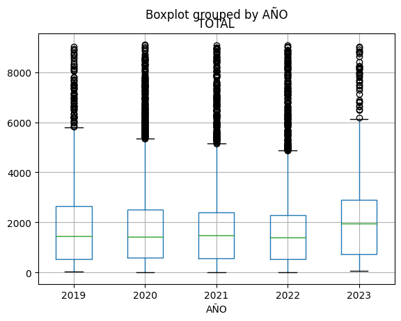

```python
df_facturacion.boxplot("TOTAL", by= "AÑO")
```

```python
#Defino grupos donde me entrega la columna Fare separada por grupos de las
#categorías de la columna sex: "male" y "female"
filtro1 = df_facturacion.TOTAL[df_facturacion.AÑO == "2019"]
filtro2 = df_facturacion.TOTAL[df_facturacion.AÑO == "2020"]
filtro3 = df_facturacion.TOTAL[df_facturacion.AÑO == "2021"]
filtro4 = df_facturacion.TOTAL[df_facturacion.AÑO == "2022"]
filtro5 = df_facturacion.TOTAL[df_facturacion.AÑO == "2023"]
```

```python
#p-value < 0.05, se rechaza la hipótesis de que todas las medias son iguales
#p-value < 0.05, implica que la variable categórica influye en la variable cuantitativa
anova= stats.f_oneway(filtro1, filtro2, filtro3, filtro4, filtro5)
anova
```

```
F_onewayResult(statistic=5.138818849008728, pvalue=0.0003910242883297321)
```

**Interpretación**

El pvalue es un porcentaje que evalua la evidencia en contra de la hipótesis nula. Cuanto más pequeño es el valor p, mayor es la evidencia en contra de la hipótesis nula. En este caso el valor es mucho más bajo de 0.05 por lo que la hipotesis se rechaza. Este resultado quiere decir que la variable categórica (Año) si influye en la variable cuantitativa. Además de esto, se pueden observar ciertos elementos de facturación elevados.

# **Conclusiones finales**

### **Conclusiones José María Colombres Elguea**

Durante esta etapa del proyecto obtuvimos estadísticas descriptivas de los archivos antes de realizar el análisis de regresión lineal, no lineal y ANOVA. Esto fue un gran avance en comparación a la primera entrega, pues aplicamos métodos más complehos y precisos para analizar la impportancia de las variables, así como predicciones y ponderaciones. Considero que estos avances son favorables para cumplir el objetivo del proyecto, pues permitirán construir un mapa adecuado de los datos para continuar haciendo modelaciones y presentar al socio formador datos de mucho más interés en tiempo real. Además estoy seguro de que cada una de las técnicas aplicadas tiene una importancia significativa; puede que en unos archivos más que en otros, pero, todos los procesos son útiles. Comenzando con la estadística descriptiva, nos ayuda a obtener información clave sobre la distribución de los datos, como medidas de tendencia central (como la media y la mediana) y medidas de dispersión (como la desviación estándar y el rango). Esto ayudó a continuar identificando outliers por ejemplo.

Por otro lado, los procesos de regresión son una de las mejores opciones para identificar y analizar la relación que tienen las variables a través de diferentes modelos y comparaciones de columnas. De esta forma se identifica información relevante e incluso algunos datos que podrían faltar y que Calor y Control pueda pasarnos para mejorar los modelos. Este proceso también es de gran ayuda para detectar posibles transformaciones de variables y evaluar la idoneidad de diferentes modelos no lineales. Finalmente ANOVA nos sirve para mejorar la clasificación de las variables a través de la varianza y de su influencia en el dataframe. De esta forma, considero que como equipo estamos encaminados hacia el aprendizaje de modelos más complejos a partir de los aplicados en esta segunda etapa del proyecto.